# Example questions

Here we have some practice deciding what type of statistical test to use in order to answer various hypotheses. Over the course of the term, we’ve learned how to run a bunch of different tests, and now we’ll put this toolkit to use!

**Some helpful things to consider when deciding which tests to run**:

- Is the **dependent variable (DV) continuous** or **categorical**?
  - If categorical, we probably want to use either a [**chi-square test**](http://www.stanford.edu/class/psych252/cheatsheets/chisquare.html) (testing for goodness of fit [1-way], or a test of dependence [2-way]) or [**logistic regression**](http://web.stanford.edu/class/psych252/tutorials/Tutorial_LogisticRegression.html)
  - If the DV is continuous, we’re most likely going to be using a [**general linear model**](http://www.stanford.edu/class/psych252/section/Week3_Section.html#lm-bootcamp) (which encompasses $t$-tests, 1-way ANOVAs, regression, multiple regression), or a [**linear mixed effects model**](http://web.stanford.edu/class/psych252/section/Mixed_models_tutorial.html) (repeated measures ANOVA, a model with both fixed and random effects).
- Are there **repeated measures**/more than one observation from a single source (subject, classroom, etc.)?
  - If so, you might want to use a mixed effects model with `lmer()` (continuous DV) or `glmer(..., family='binomial')` (binary categorical DV)!
- Is there a **causal model** being tested? Does it warrant [**mediation**](http://web.stanford.edu/class/psych252/section/Section_week7.html#mediation-analysis) analyses (x causes y, but is mediated by z such that x -> z -> y)? [**Partial correlation**](http://web.stanford.edu/class/psych252/section/Section_week7.html#partial-correlation) (x independently causes y and z; y and z are not causally related)?

**Other suggestions**:

- Plot your data!
- Look at your data! Are there NA values to deal with? Do you need to reshape the dataframe into long form (e.g., for `lmer()`)?
- Make sure variables are coded appropriately (e.g., factors)
- Generate a hypothesis before making your contrasts; rely on your plots as well!
- Center continuous variables if necessary; contrast/effect code categorical variables too if including an interaction in your model if you want to interpret lower order effects as “main effects” controlling for the other variables in your model, rather than simple effects.
- Test for interactions if possible
- If you have a continuous IV, is the effect on your DV linear, or is there a higher order effect (e.g., polynomial)?
- Compare models using `anova()` to justify which one is best!

## Scenario 1

We want to know whether the perception that jury members hold of a defendant might influence the outcome of a case (i.e. whether individual jurors vote guilty or not guilty). To study this the experimenter had participants read a case outline (each outline was taken from a different defendant in the county) and then answer questions about the case. The case outline states the main facts of a robbery, including eye-witness testimony about the identity and behavior of the robber. Participants are asked:

- Do you think that the defendant is guilty? (`guiltcat`: 1 = Definitely Not Guilty, 2 = Probably Not Guilty, 3 = Probably Guilty, or 4 = Definitely Guilty)
- On the basis of the evidence, do you think that the defendant is mentally ill? (`mentill`: 1 = Yes or 0 = No)
- Using a 0 (Very Low) to 10 (Very High) scale, state how much you think the defendant is a future threat (`futhrt`) to society.

```r
df_jury = read.csv('http://www.stanford.edu/class/psych252/data/mentillness.csv')
str(df_jury)
```

```
## 'data.frame':    240 obs. of  9 variables:
##  $ guilt   : int  1 1 1 1 1 1 1 1 1 1 ...
##  $ mentill : int  1 1 1 1 1 1 1 1 1 1 ...
##  $ futhrt  : int  4 3 8 5 6 7 3 3 4 4 ...
##  $ se      : num  0.0518 0.0518 0.0518 0.0518 0.0518 ...
##  $ z       : num  2.51 2.51 2.51 2.51 2.51 ...
##  $ pp      : num  0.00599 0.00599 0.00599 0.00599 0.00599 ...
##  $ futthcat: int  4 3 6 5 6 6 3 3 4 4 ...
##  $ guiltq  : num  0.3391 -0.0293 0.4792 0.8309 0.3702 ...
##  $ guiltcat: int  2 2 3 3 2 1 1 1 2 4 ...
```

```
## stat_bin: binwidth defaulted to range/30. Use 'binwidth = x' to adjust this.
## stat_bin: binwidth defaulted to range/30. Use 'binwidth = x' to adjust this.
## stat_bin: binwidth defaulted to range/30. Use 'binwidth = x' to adjust this.
## stat_bin: binwidth defaulted to range/30. Use 'binwidth = x' to adjust this.
```

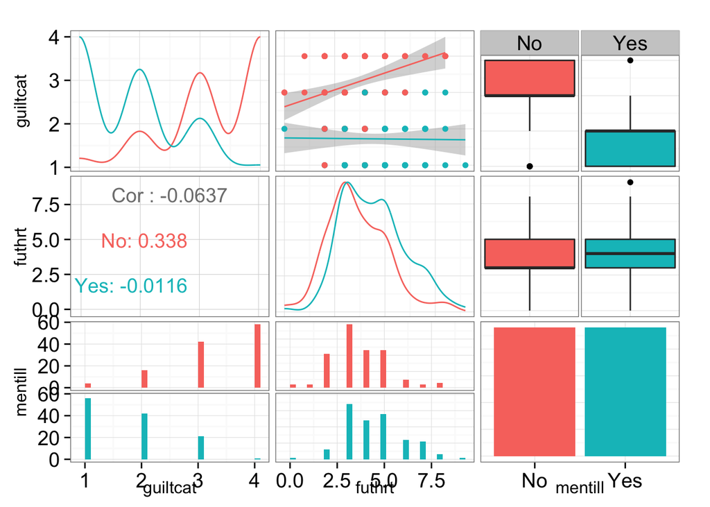

```r
df_jury = df_jury %>%
  mutate(mentill=factor(mentill,levels=c(0,1),labels=c("No","Yes")))
df_jury = df_jury[,c('guiltcat', 'futhrt', 'mentill')]
plot_dataframe(df_jury, color_var = 'mentill')
```

### Question 1

Before we answer the main research question, the researchers are curious if the distribution of defendants deemed mentally ill is the same as last year. The proportions last year were no: .75, yes: .25.

**What type of test would we use to answer this question?**

A **chi-square goodness of fit test** (1-way)! We want to know whether the data is consistent with the specified distribution from last year (.75, .25), and we can use the chi-square test to figure this out!

```r
addmargins(table(df_jury$mentill))
```

```
##
##  No Yes Sum
## 120 120 240
```

```r
chisqres = chisq.test(table(df_jury$mentill), p = c(.75, .25))
chisqres
```

```
##
##  Chi-squared test for given probabilities
##
## data:  table(df_jury$mentill)
## X-squared = 80, df = 1, p-value < 2.2e-16
```

```r
chisqres$expected
```

```
##  No Yes
## 180  60
```

No, the observed counts of defendents mental illness status was significantly different from the distribution of last year, $\chi^2$ (N=240, df=1) = 80, p < 0.001. This year fewer defendants were deemed not mentally ill, and more were deemed mentally ill; specifically, this year the proportions were no:.5, yes:.5, instead of no:.75, yes:.25.

### Question 2

The researchers’ believe that a defendant’s perceived future threat and mental illness status may influence the jury’s perception of guilt.

**What type of test should we use to test this question?**

We should use **multiple regression** using `lm` (a general linear model). We have a continuous dependent variable (`guiltcat` – note that even though we have category in the name, it’s a 4 point scale!), and both a categorical and continuous independent variable. We probably will want to contrast code the categorical IV to begin with, and let’s center our continuous IV so we can interpret the other terms in our model.

```r
# Create contast for mental illness
contrasts(df_jury$mentill) = cbind(NovsYes = c(1, -1))
contrasts(df_jury$mentill)
```

```
##     NovsYes
## No        1
## Yes      -1
```

```r
# Look at main effects
rs1 = lm(guiltcat ~ mentill, data=df_jury)
summary(rs1)
```

```
##
## Call:
## lm(formula = guiltcat ~ mentill, data = df_jury)
##
## Residuals:
##     Min      1Q  Median      3Q     Max
## -2.2833 -0.7250  0.2750  0.7167  2.2750
##
## Coefficients:
##                Estimate Std. Error t value Pr(>|t|)
## (Intercept)     2.50417    0.05163   48.50   <2e-16 ***
## mentillNovsYes  0.77917    0.05163   15.09   <2e-16 ***
## ---
## Signif. codes:  0 '***' 0.001 '**' 0.01 '*' 0.05 '.' 0.1 ' ' 1
##
## Residual standard error: 0.7999 on 238 degrees of freedom
## Multiple R-squared:  0.4889, Adjusted R-squared:  0.4868
## F-statistic: 227.7 on 1 and 238 DF,  p-value: < 2.2e-16
```

```r
rs2 = lm(guiltcat ~ scale(futhrt, scale=F), data=df_jury)
summary(rs2)
```

```
##
## Call:
## lm(formula = guiltcat ~ scale(futhrt, scale = F), data = df_jury)
##
## Residuals:
##     Min      1Q  Median      3Q     Max
## -1.5952 -0.8340  0.3376  0.6399  1.6735
##
## Coefficients:
##                          Estimate Std. Error t value Pr(>|t|)
## (Intercept)               2.50417    0.07208  34.741   <2e-16 ***
## scale(futhrt, scale = F) -0.04478    0.04545  -0.985    0.326
## ---
## Signif. codes:  0 '***' 0.001 '**' 0.01 '*' 0.05 '.' 0.1 ' ' 1
##
## Residual standard error: 1.117 on 238 degrees of freedom
## Multiple R-squared:  0.004062,   Adjusted R-squared:  -0.0001226
## F-statistic: 0.9707 on 1 and 238 DF,  p-value: 0.3255
```

```r
# Explore additive and interactive models
rs3a = lm(guiltcat ~ mentill + scale(futhrt, scale=F), data=df_jury)

# Some model comparisons to see if adding both terms is warranted
anova(rs1, rs3a)
```

```
## Analysis of Variance Table
##
## Model 1: guiltcat ~ mentill
## Model 2: guiltcat ~ mentill + scale(futhrt, scale = F)
##   Res.Df    RSS Df Sum of Sq      F  Pr(>F)
## 1    238 152.29
## 2    237 148.26  1    4.0359 6.4518 0.01172 *
## ---
## Signif. codes:  0 '***' 0.001 '**' 0.01 '*' 0.05 '.' 0.1 ' ' 1
```

```r
anova(rs2, rs3a)
```

```
## Analysis of Variance Table
##
## Model 1: guiltcat ~ scale(futhrt, scale = F)
## Model 2: guiltcat ~ mentill + scale(futhrt, scale = F)
##   Res.Df    RSS Df Sum of Sq      F    Pr(>F)
## 1    238 296.79
## 2    237 148.26  1    148.53 237.44 < 2.2e-16 ***
## ---
## Signif. codes:  0 '***' 0.001 '**' 0.01 '*' 0.05 '.' 0.1 ' ' 1
```

```r
rs3b = lm(guiltcat ~ mentill * scale(futhrt, scale=F), data = df_jury)
anova(rs3a, rs3b)
```

```
## Analysis of Variance Table
##
## Model 1: guiltcat ~ mentill + scale(futhrt, scale = F)
## Model 2: guiltcat ~ mentill * scale(futhrt, scale = F)
##   Res.Df    RSS Df Sum of Sq      F   Pr(>F)
## 1    237 148.26
## 2    236 143.08  1    5.1774 8.5398 0.003812 **
## ---
## Signif. codes:  0 '***' 0.001 '**' 0.01 '*' 0.05 '.' 0.1 ' ' 1
```

```r
summary(rs3b)
```

```
##
## Call:
## lm(formula = guiltcat ~ mentill * scale(futhrt, scale = F), data = df_jury)
##
## Residuals:
##     Min      1Q  Median      3Q     Max
## -2.3516 -0.7218  0.1484  0.4624  2.2725
##
## Coefficients:
##                                         Estimate Std. Error t value
## (Intercept)                              2.54251    0.05195  48.946
## mentillNovsYes                           0.81524    0.05195  15.694
## scale(futhrt, scale = F)                 0.09019    0.03281   2.749
## mentillNovsYes:scale(futhrt, scale = F)  0.09587    0.03281   2.922
##                                         Pr(>|t|)
## (Intercept)                              < 2e-16 ***
## mentillNovsYes                           < 2e-16 ***
## scale(futhrt, scale = F)                 0.00644 **
## mentillNovsYes:scale(futhrt, scale = F)  0.00381 **
## ---
## Signif. codes:  0 '***' 0.001 '**' 0.01 '*' 0.05 '.' 0.1 ' ' 1
##
## Residual standard error: 0.7786 on 236 degrees of freedom
## Multiple R-squared:  0.5199, Adjusted R-squared:  0.5138
## F-statistic: 85.18 on 3 and 236 DF,  p-value: < 2.2e-16
```

```r
# Explore interaction
contrasts(df_jury$mentill) = cbind(No=c(0, 1))
contrasts(df_jury$mentill)
```

```
##     No
## No   0
## Yes  1
```

```r
rs4 = lm(guiltcat ~ mentill * scale(futhrt, scale=F), data=df_jury)
summary(rs4)
```

```
##
## Call:
## lm(formula = guiltcat ~ mentill * scale(futhrt, scale = F), data = df_jury)
##
## Residuals:
##     Min      1Q  Median      3Q     Max
## -2.3516 -0.7218  0.1484  0.4624  2.2725
##
## Coefficients:
##                                    Estimate Std. Error t value Pr(>|t|)
## (Intercept)                         3.35776    0.07360  45.621  < 2e-16
## mentillNo                          -1.63049    0.10389 -15.694  < 2e-16
## scale(futhrt, scale = F)            0.18606    0.04775   3.896 0.000127
## mentillNo:scale(futhrt, scale = F) -0.19173    0.06561  -2.922 0.003812
##
## (Intercept)                        ***
## mentillNo                          ***
## scale(futhrt, scale = F)           ***
## mentillNo:scale(futhrt, scale = F) **
## ---
## Signif. codes:  0 '***' 0.001 '**' 0.01 '*' 0.05 '.' 0.1 ' ' 1
##
## Residual standard error: 0.7786 on 236 degrees of freedom
## Multiple R-squared:  0.5199, Adjusted R-squared:  0.5138
## F-statistic: 85.18 on 3 and 236 DF,  p-value: < 2.2e-16
```

```r
contrasts(df_jury$mentill) = cbind(Yes=c(1, 0))
contrasts(df_jury$mentill)
```

```
##     Yes
## No    1
## Yes   0
```

```r
rs5 = lm(guiltcat ~ mentill * scale(futhrt, scale=F), data=df_jury)
summary(rs5)
```

```
##
## Call:
## lm(formula = guiltcat ~ mentill * scale(futhrt, scale = F), data = df_jury)
##
## Residuals:
##     Min      1Q  Median      3Q     Max
## -2.3516 -0.7218  0.1484  0.4624  2.2725
##
## Coefficients:
##                                      Estimate Std. Error t value Pr(>|t|)
## (Intercept)                          1.727271   0.073322  23.557  < 2e-16
## mentillYes                           1.630486   0.103890  15.694  < 2e-16
## scale(futhrt, scale = F)            -0.005677   0.044994  -0.126  0.89971
## mentillYes:scale(futhrt, scale = F)  0.191735   0.065611   2.922  0.00381
##
## (Intercept)                         ***
## mentillYes                          ***
## scale(futhrt, scale = F)
## mentillYes:scale(futhrt, scale = F) **
## ---
## Signif. codes:  0 '***' 0.001 '**' 0.01 '*' 0.05 '.' 0.1 ' ' 1
##
## Residual standard error: 0.7786 on 236 degrees of freedom
## Multiple R-squared:  0.5199, Adjusted R-squared:  0.5138
## F-statistic: 85.18 on 3 and 236 DF,  p-value: < 2.2e-16
```

Some stats:

```r
library(doBy)
summaryBy(guiltcat~mentill, data = df_jury,
          FUN = function(x) { c(m = mean(x), s = sd(x)) } )
```

```
##   mentill guiltcat.m guiltcat.s
## 1      No   3.283333  0.8217969
## 2     Yes   1.725000  0.7774392
```

Plot with standard error bars (as you might do in a paper):

```r
# Load in some helper functions
source('http://www.stanford.edu/class/psych252/data/Plotting_means_errorbars.R')

df_summary = summarySE(df_jury, measurevar='guiltcat', groupvars=c('mentill'))
df_summary
```

```
##   mentill   N guiltcat        sd         se       ci
## 1      No 120 3.283333 0.8217969 0.07501945 0.148546
## 2     Yes 120 1.725000 0.7774392 0.07097017 0.140528
```

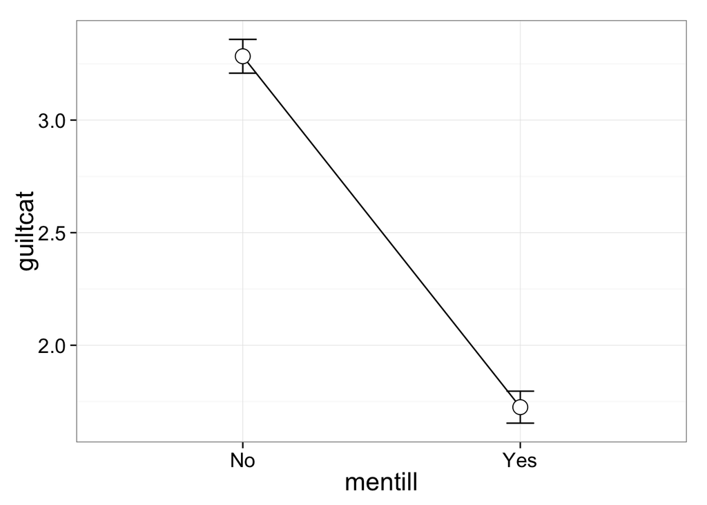

```r
ggplot(df_summary, aes(x=mentill, y=guiltcat, group=1)) +
    geom_errorbar(aes(ymin=guiltcat-se, ymax=guiltcat+se), colour="black", width=.1) +
    geom_line() +
    geom_point(size=5, shape=21, fill="white") # 21 is filled circle
```

**Write up, including (1) the statistics (note the reporting of descriptive stats!), (2) the direction of the effect(s), and (3) a quick explanation about what the stats mean:**

However, and most importantly, the model that best explains the data includes an interaction between mental illness and future threat (adjusted $R^2 = 0.51, F(3, 236) = 85.18, p < 0.001$). This interactive model does a significantly better job fitting the data than an additive model, $F(1,$ 236 $) = 8.54, p < 0.01$. Here we observe a significant interaction between perceived future threat and mental illness on guilt ratings, $t(236)=2.92, p < 0.01$. Specifically, for those perceived as not mentally ill, we observed a significant simple effect of future threat on guilt, such that as future threat increases by one unit, guilt increases by 0.19 points, $t(236) = 3.90, p < 0.001$. However, for those perceived as mentally ill, there is not a significant simple effect of future threat on guilt, $b=-0.006, t(236) = -0.126, p = 0.90$. This suggests that the jury believes that since non-mentally ill people can control their actions, the more of a future threat they are to society, the guiltier they should be. However, for mentally ill people, since their actions might be out of their control, even if they might be a greater future threat to society this future threat shouldn’t influence their current guilt.

Further, this interaction is qualified by significant lower order effects of mental illness and future threat; controlling for future threat, mental illness …. [here you would continue writing up lower order results! while the interaction is where the meat of the analysis is at, it’s often preferable to report the full results].

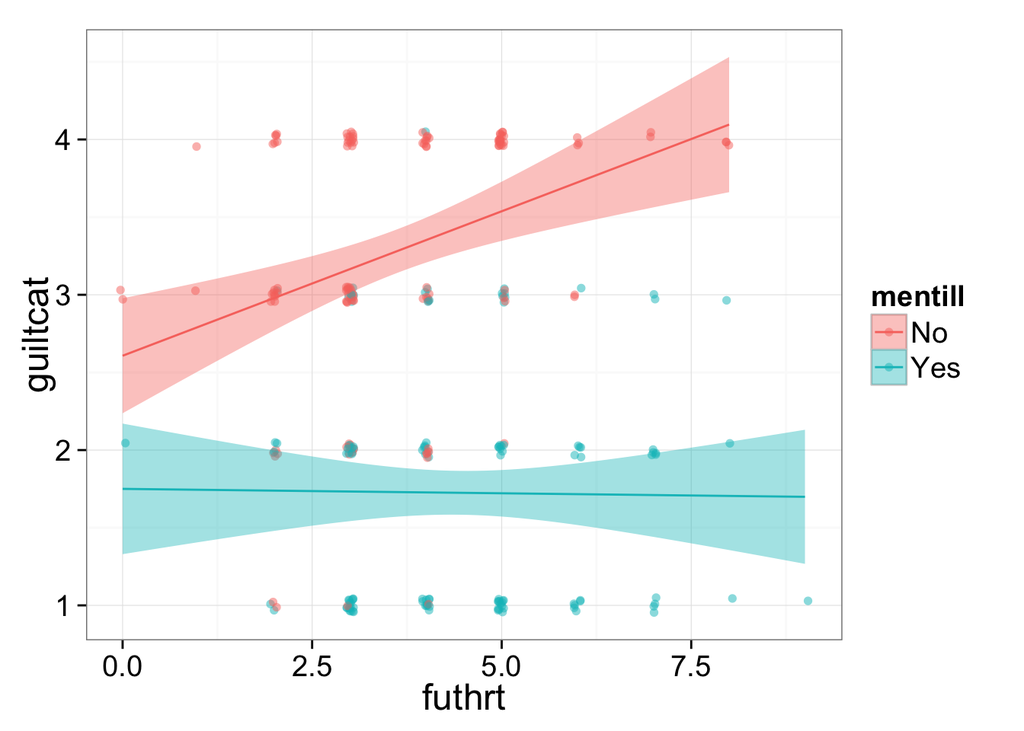

```r
ggplot(df_jury, aes(futhrt, guiltcat, color=mentill, fill=mentill)) +
  geom_point(position=position_jitter(height=0.05,width=0.05), alpha=.5) +
  geom_smooth(method='lm')
```

### Question 3

Another research is curious if perceived future threat actually influences whether a defendant is classified as mentally ill or not. The researcher believes that perhaps people are more likely to be considered as mentally ill if they commit horrible crimes that make them a large future threat to society.

**What type of test would we use to answer this question?**

**Logistic regression** works here, since we have a categorical dependent variable, and a continuous IV. We only have one observation from each person, so we only have fixed effects (no random effects to consider) and we can just use `glm(..., family='binomial')`, rather than `glmer(..., family='binomial')`.

```r
summary(glm(mentill ~ futhrt, data=df_jury, family='binomial'))
```

```
##
## Call:
## glm(formula = mentill ~ futhrt, family = "binomial", data = df_jury)
##
## Deviance Residuals:
##      Min        1Q    Median        3Q       Max
## -1.78269  -1.03387  -0.04679   1.17988   1.78788
##
## Coefficients:
##             Estimate Std. Error z value Pr(>|z|)
## (Intercept) -1.37230    0.38462  -3.568 0.000360 ***
## futhrt       0.34162    0.09046   3.777 0.000159 ***
## ---
## Signif. codes:  0 '***' 0.001 '**' 0.01 '*' 0.05 '.' 0.1 ' ' 1
##
## (Dispersion parameter for binomial family taken to be 1)
##
##     Null deviance: 332.71  on 239  degrees of freedom
## Residual deviance: 316.89  on 238  degrees of freedom
## AIC: 320.89
##
## Number of Fisher Scoring iterations: 4
```

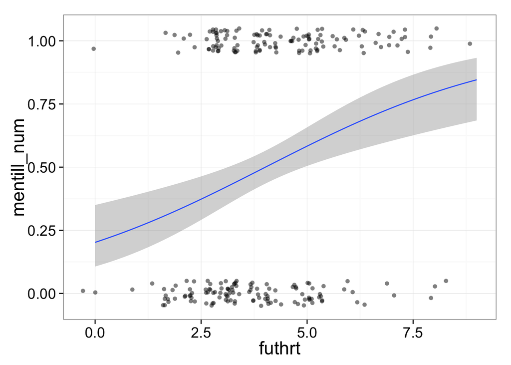

```r
df_jury$mentill_num = as.numeric(df_jury$mentill) - 1
ggplot(df_jury, aes(futhrt, mentill_num)) +
  geom_point(position=position_jitter(heigh=.05), alpha=.5) +
  stat_smooth(method='glm', family='binomial')
```

As future threat increases by one unit, the odds of being classified as mentally ill increase by 1.4072255, $z=3.78, p < 0.001$. It looks like the researcher is correct!

```r
summaryBy(futhrt ~ mentill, data=df_jury, FUN = function(x) { c(m = mean(x), s = sd(x)) })
```

```
##   mentill futhrt.m futhrt.s
## 1      No 3.633333 1.494715
## 2     Yes 4.433333 1.586356
```

## Scenario 2

### Question 4

A group of researchers has data from 50 states, and they hypothesize a causal model that low high school graduation rates lead to illiteracy, and illiteracy reduces income.

How can we test this hypothesis?

We can use **mediation**! Here, it might be the case that low high school graduation rates (`x`) lead to reductions in income (`y`), or this effect may be mediated by illiteracy (our mediator variable, `z`), as predicted.

```r
df = data.frame(state.x77)
str(df)
```

```
## 'data.frame':    50 obs. of  8 variables:
##  $ Population: num  3615 365 2212 2110 21198 ...
##  $ Income    : num  3624 6315 4530 3378 5114 ...
##  $ Illiteracy: num  2.1 1.5 1.8 1.9 1.1 0.7 1.1 0.9 1.3 2 ...
##  $ Life.Exp  : num  69 69.3 70.5 70.7 71.7 ...
##  $ Murder    : num  15.1 11.3 7.8 10.1 10.3 6.8 3.1 6.2 10.7 13.9 ...
##  $ HS.Grad   : num  41.3 66.7 58.1 39.9 62.6 63.9 56 54.6 52.6 40.6 ...
##  $ Frost     : num  20 152 15 65 20 166 139 103 11 60 ...
##  $ Area      : num  50708 566432 113417 51945 156361 ...
```

```r
model1 = lm(Income ~ HS.Grad, data=df) #c
c_val = model1$coefficients['HS.Grad']; c_val
```

```
## HS.Grad
## 47.1623
```

```r
model2 = lm(Illiteracy ~ HS.Grad, data=df) #a
a_val = model2$coefficients['HS.Grad']
se_a_val = summary(model2)$coefficients[2,2] # get SE
summary(model2)
```

```
##
## Call:
## lm(formula = Illiteracy ~ HS.Grad, data = df)
##
## Residuals:
##     Min      1Q  Median      3Q     Max
## -0.6605 -0.3064 -0.1225  0.1815  1.1660
##
## Coefficients:
##             Estimate Std. Error t value Pr(>|t|)
## (Intercept)  3.80389    0.44093   8.627 2.53e-11 ***
## HS.Grad     -0.04960    0.00821  -6.041 2.17e-07 ***
## ---
## Signif. codes:  0 '***' 0.001 '**' 0.01 '*' 0.05 '.' 0.1 ' ' 1
##
## Residual standard error: 0.4642 on 48 degrees of freedom
## Multiple R-squared:  0.4319, Adjusted R-squared:  0.4201
## F-statistic: 36.49 on 1 and 48 DF,  p-value: 2.172e-07
```

```r
model3 = lm(Income ~ HS.Grad + Illiteracy, data=df) #b and c'
b_val = model3$coefficients['Illiteracy']
cprime_val = model3$coefficients['HS.Grad']; cprime_val
```

```
##  HS.Grad
## 44.55179
```

```r
se_b_val = summary(model3)$coefficients[3,2]
summary(model3)
```

```
##
## Call:
## lm(formula = Income ~ HS.Grad + Illiteracy, data = df)
##
## Residuals:
##      Min       1Q   Median       3Q      Max
## -1076.08  -307.96   -52.45   255.01  1291.02
##
## Coefficients:
##             Estimate Std. Error t value Pr(>|t|)
## (Intercept)  2131.33     745.89   2.857 0.006344 **
## HS.Grad        44.55      11.54   3.861 0.000344 ***
## Illiteracy    -52.64     152.89  -0.344 0.732170
## ---
## Signif. codes:  0 '***' 0.001 '**' 0.01 '*' 0.05 '.' 0.1 ' ' 1
##
## Residual standard error: 491.7 on 47 degrees of freedom
## Multiple R-squared:  0.3859, Adjusted R-squared:  0.3597
## F-statistic: 14.77 on 2 and 47 DF,  p-value: 1.057e-05
```

```r
se_ab <- sqrt(b_val^2*
                se_a_val^2+a_val^2
              *se_b_val^2+se_a_val^2*se_b_val^2)
se_ab # standard error of a*b
```

```
## Illiteracy
##   7.697791
```

```r
sobel_stat = a_val*b_val/se_ab; sobel_stat
```

```
##   HS.Grad
## 0.3391239
```

```r
p_s_ab <- pnorm(sobel_stat, lower.tail=F)
p_s_ab # p of ratio of a*b over its s.e.
```

```
##   HS.Grad
## 0.3672582
```

The relationship between HS graduation rates and income was not mediated by illiteracy. While the regression coefficient between HS graduation rates and illiteracy was statistically significant (-0.05, $t(48)=-6.041, p < 0.001$), the regression coefficient between illiteracy and income, when controlling for HS graduation rates, was not significant (-52.64, $t(47)= -0.344, p=0.73$). The indirect effect was $(-0.05)(-52.64) = 2.61$. We tested the significance of this indirect effect using the Sobel test, and found that the mediation was not significant, $z=0.34, p = 0.37$. It appears that HS graduation rates are a good indicator of income, perhaps because just the high school degree boosts income.

## Scenario 3

### Question 5

Here we have data about the price of different items sold in the supermarket. The researchers collected data from 4 different stores, and within each store collected information about the prices of different items. Specifically, we are interested in whether non-food products are more expensive than food products. Then, within non-food products, we want to know if aspirin is more expensive than laundry detergent. Within food products, we want to know if potatoes are more expensive than lettuce.

**What type of test would we use to test this hypothesis?**

We could use a **linear mixed effects model**! We’re trying to predict a continuous DV (price), so we want to use a linear model (not logistic regression), and we’re using a categorical IV, so we’ll want to make sure we choose the appropriate contrast coding for our question. Secondly, we note that there are **repeated measurements** from the same stores; that is, our observations are not all independent – some of the items came from the same store, and thus might have similar prices.

For our mixed effects model, our fixed effect is the item type; we’ll create contrast codes to test the specific predictions from our hypothesis. We also can include a random effect (only an intercept in this case) for store; specifically, the average price might differ across stores, if one store is in an area with a lower cost of living, etc.

```r
d = read.table('http://ww2.coastal.edu/kingw/statistics/R-tutorials/text/groceries.txt', header=T)
str(d)
```

```
## 'data.frame':    10 obs. of  5 variables:
##  $ subject: Factor w/ 10 levels "aspirin","bread",..: 7 9 8 4 2 3 5 10 6 1
##  $ storeA : num  1.17 1.77 1.49 0.65 1.58 3.13 2.09 0.62 5.89 4.46
##  $ storeB : num  1.78 1.98 1.69 0.99 1.7 3.15 1.88 0.65 5.99 4.84
##  $ storeC : num  1.29 1.99 1.79 0.69 1.89 2.99 2.09 0.65 5.99 4.99
##  $ storeD : num  1.29 1.99 1.59 1.09 1.89 3.09 2.49 0.69 6.99 5.15
```

```r
d = d[d$subject %in% c('aspirin', 'laundry.detergent', 'lettuce', 'potatoes'),]
d$subject = factor(d$subject)
```

```r
d = gather(d, 'store', 'price', 2:5)
names(d) = c('item', 'store', 'price')
str(d)
```

```
## 'data.frame':    16 obs. of  3 variables:
##  $ item : Factor w/ 4 levels "aspirin","laundry.detergent",..: 3 4 2 1 3 4 2 1 3 4 ...
##  $ store: Factor w/ 4 levels "storeA","storeB",..: 1 1 1 1 2 2 2 2 3 3 ...
##  $ price: num  1.17 1.77 5.89 4.46 1.78 1.98 5.99 4.84 1.29 1.99 ...
```

```r
# Look at mean prices
with(d, aggregate(price ~ store, data=d, FUN=mean))
```

```
##    store  price
## 1 storeA 3.3225
## 2 storeB 3.6475
## 3 storeC 3.5650
## 4 storeD 3.8550
```

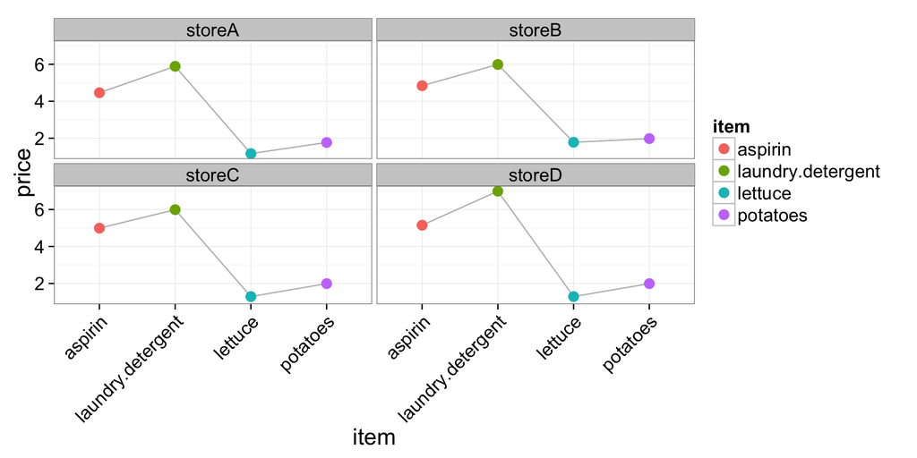

```r
p = ggplot(d, aes(x=item, y=price, color=item)) +
    geom_smooth(aes(group=1), method='loess', color='gray') +
    geom_point(size=4) +
    facet_wrap(~store, ncol = 2) +
  theme(axis.text.x = element_text(angle = 45, hjust=1))
p
```

```r
contrasts(d$item)
```

```
##                   laundry.detergent lettuce potatoes
## aspirin                           0       0        0
## laundry.detergent                 1       0        0
## lettuce                           0       1        0
## potatoes                          0       0        1
```

```r
contrasts(d$item) = cbind(OthervsFood=c(1, 1, -1, -1),
                          AspirinvLaundry=c(-1, 1, 0, 0),
                          LettucevPotatoes=c(0, 0, -1, 1))
# check to make sure contrasts are orthogonal!
contrasts(d$item)
```

```
##                   OthervsFood AspirinvLaundry LettucevPotatoes
## aspirin                     1              -1                0
## laundry.detergent           1               1                0
## lettuce                    -1               0               -1
## potatoes                   -1               0                1
```

```r
rs0 = lm(price ~ item, data=d)

rs1 = lmer(price ~ item + (1| store), data=d, REML=FALSE)
anova(rs1, rs0)
```

```
## Data: d
## Models:
## ..1: price ~ item
## object: price ~ item + (1 | store)
##        Df    AIC    BIC  logLik deviance  Chisq Chi Df Pr(>Chisq)
## ..1     5 15.541 19.404 -2.7703   5.5406
## object  6 16.304 20.939 -2.1519   4.3037 1.2369      1     0.2661
```

```r
summary(rs1)
```

```
## Linear mixed model fit by maximum likelihood t-tests use Satterthwaite
##   approximations to degrees of freedom [lmerMod]
## Formula: price ~ item + (1 | store)
##    Data: d
##
##      AIC      BIC   logLik deviance df.resid
##     16.3     20.9     -2.2      4.3       10
##
## Scaled residuals:
##     Min      1Q  Median      3Q     Max
## -1.0200 -0.7107 -0.2074  0.3724  2.5207
##
## Random effects:
##  Groups   Name        Variance Std.Dev.
##  store    (Intercept) 0.02090  0.1446
##  Residual             0.06187  0.2487
## Number of obs: 16, groups:  store, 4
##
## Fixed effects:
##                      Estimate Std. Error       df t value Pr(>|t|)
## (Intercept)           3.59750    0.09536  4.00000  37.727 2.95e-06 ***
## itemOthervsFood       1.94000    0.06219 12.00000  31.196 7.40e-13 ***
## itemAspirinvLaundry   0.67750    0.08795 12.00000   7.704 5.52e-06 ***
## itemLettucevPotatoes  0.27500    0.08795 12.00000   3.127  0.00874 **
## ---
## Signif. codes:  0 '***' 0.001 '**' 0.01 '*' 0.05 '.' 0.1 ' ' 1
##
## Correlation of Fixed Effects:
##             (Intr) itmOtF itmAsL
## itmOthrvsFd 0.000
## itmAsprnvLn 0.000  0.000
## itmLttcvPtt 0.000  0.000  0.000
```

```r
coef(rs1)$store['(Intercept)']
```

```
##        (Intercept)
## storeA    3.439456
## storeB    3.626235
## storeC    3.578822
## storeD    3.745487
```

```r
summary(rs0)
```

```
##
## Call:
## lm(formula = price ~ item, data = d)
##
## Residuals:
##      Min       1Q   Median       3Q      Max
## -0.40000 -0.21562 -0.05625  0.07562  0.77500
##
## Coefficients:
##                      Estimate Std. Error t value Pr(>|t|)
## (Intercept)           3.59750    0.08306  43.315 1.49e-14 ***
## itemOthervsFood       1.94000    0.08306  23.358 2.26e-11 ***
## itemAspirinvLaundry   0.67750    0.11746   5.768 8.91e-05 ***
## itemLettucevPotatoes  0.27500    0.11746   2.341   0.0373 *
## ---
## Signif. codes:  0 '***' 0.001 '**' 0.01 '*' 0.05 '.' 0.1 ' ' 1
##
## Residual standard error: 0.3322 on 12 degrees of freedom
## Multiple R-squared:  0.9799, Adjusted R-squared:  0.9748
## F-statistic: 194.8 on 3 and 12 DF,  p-value: 1.93e-10
```

```r
AIC(rs0, rs1)
```

```
##     df      AIC
## rs0  5 15.54057
## rs1  6 16.30370
```

```r
# rs2 = lmer(price ~ item + (1 + item | store), data=d)
```

Interestingly, our analyses revealed that when looking at how item type influences price, allowing the regression intercept (i.e., mean price in this case) to vary by store did not significantly improve model fit beyond that of a general linear model with only fixed effects, $\chi^2 (1) = 1.24, p = 0.27$. Here, we’re faced with a decision; should we stick with the simpler model, or include the random intercepts to keep our model “maximal” and since we know the observations from the same store are not independent. In our mixed effect model, the variance of the intercepts estimated for the different stores is quite small (var = 0.02, relative to a variance of 0.06 for the residual variance), and the intercepts range from 3.4 to 3.7. Thus, it appears as though the different stores don’t have very different mean prices. Further, across stores, it looks as though the parameter estimates/slopes for our contrasts would be quite similar, even though we can’t include random slopes for item in our model due to lack of data. Finally, we should interpret the fixed effects from our best model, following the same rules as writing up `lm()` results! We can use `{lmerTest}` to get approximations (Satterthwaite approximations by default) for dfs to calculate p-values.

For getting some measure of $R^2$ for mixed effect models, check out [this post](http://jonlefcheck.net/2013/03/13/r2-for-linear-mixed-effects-models/).

## Some extra code for within-subject standard error bars

When you have repeated measures, often it will give you a better idea of significance by plotting with **within-subject** standard error bars; this is because the within-subject error bars are often smaller than the regular standard error bars, especially if your subjects have very different means (/intercepts). The code to generate within-subject SE bars was taken from the R cookbook. As stated on their page, “The graph of individual data shows that there is a consistent trend for the within-subjects variable condition, but this would not necessarily be revealed by taking the regular standard errors (or confidence intervals) for each group. The method in Morey (2008) and Cousineau (2005) essentially normalizes the data to remove the between-subject variability and calculates the variance from this normalized data”.

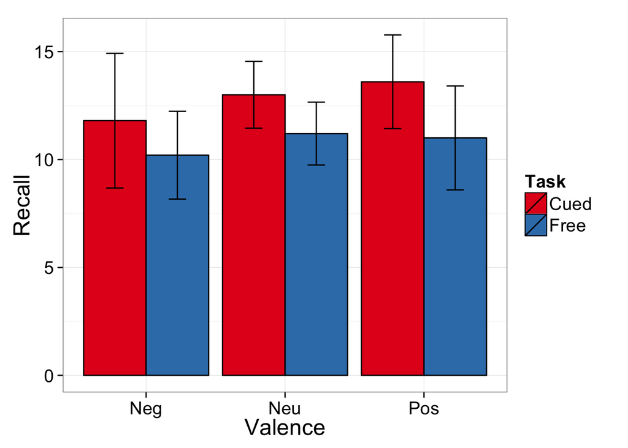

```r
d = read.table('http://www.stanford.edu/class/psych252/data/ex4.txt')
ds <- summarySEwithin(d, measurevar="Recall",
                      withinvars=c("Task", "Valence"), idvar="Subject")

ggplot(ds, aes(x=Valence, y=Recall, fill=Task)) +
    geom_bar(position=position_dodge(.9), colour="black", stat="identity") +
    geom_errorbar(position=position_dodge(.9), width=.25,
                  aes(ymin=Recall-ci, ymax=Recall+ci)) +
    scale_fill_brewer(palette="Set1")
```

## Scenario 4

### Question 6

Here we have some data from a sleep study with 10 subjects (`ID`). The subjects came into the lab twice, a week apart, and were administered one of two drugs (`group`) to help them sleep on each visit (they got each drug over the course of the 2 visits). The researchers are interested in whether drug 2 is better than drug 1 at increases the number of hours of sleep the subjects get (`extra`).

**What test should we use to test this hypothesis?**

Since we have multiple observations from each subject, we should use `lmer` to run a linear mixed effect model! We have a fixed effect of group/drug that is of interest, with a specific contrast we can test. Since this variable is a within-subjects variable, we can include a random intercept for subjects to see if that improves the model fit.

```r
ds = data.frame(sleep)
str(ds)
```

```
## 'data.frame':    20 obs. of  3 variables:
##  $ extra: num  0.7 -1.6 -0.2 -1.2 -0.1 3.4 3.7 0.8 0 2 ...
##  $ group: Factor w/ 2 levels "1","2": 1 1 1 1 1 1 1 1 1 1 ...
##  $ ID   : Factor w/ 10 levels "1","2","3","4",..: 1 2 3 4 5 6 7 8 9 10 ...
```

Plot the data and look at summary stats:

```r
dsum <- summarySEwithin(ds, measurevar="extra",
                      withinvars=c("group"), idvar="ID")
dsum
```

```
##   group  N extra extra_norm        sd        se        ci
## 1     1 10  0.75       0.75 0.8697381 0.2750354 0.6221732
## 2     2 10  2.33       2.33 0.8697381 0.2750354 0.6221732
```

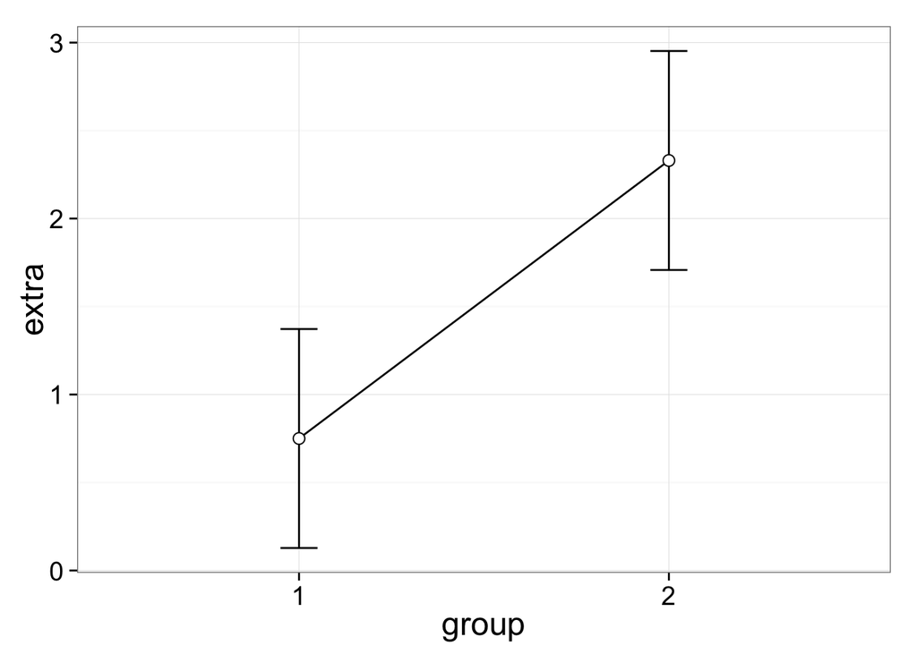

```r
ggplot(dsum, aes(x=group, y=extra, group=1)) +
    geom_line() +
    geom_errorbar(width=.1, aes(ymin=extra-ci, ymax=extra+ci)) +
    geom_point(shape=21, size=3, fill="white")
```

```r
contrasts(ds$group) = cbind(TwovOne=c(-1, 1))
contrasts(ds$group)
```

```
##   TwovOne
## 1      -1
## 2       1
```

```r
rs0 = lm(extra ~ group, data=ds)
rs1 = lmer(extra ~ group + (1|ID), data=ds, REML=FALSE)
anova(rs1, rs0)
```

```
## Data: ds
## Models:
## ..1: extra ~ group
## object: extra ~ group + (1 | ID)
##        Df    AIC    BIC  logLik deviance  Chisq Chi Df Pr(>Chisq)
## ..1     3 86.296 89.283 -40.148   80.296
## object  4 78.505 82.488 -35.252   70.505 9.7908      1   0.001754 **
## ---
## Signif. codes:  0 '***' 0.001 '**' 0.01 '*' 0.05 '.' 0.1 ' ' 1
```

```r
summary(rs1)
```

```
## Linear mixed model fit by maximum likelihood t-tests use Satterthwaite
##   approximations to degrees of freedom [lmerMod]
## Formula: extra ~ group + (1 | ID)
##    Data: ds
##
##      AIC      BIC   logLik deviance df.resid
##     78.5     82.5    -35.3     70.5       16
##
## Scaled residuals:
##      Min       1Q   Median       3Q      Max
## -1.72210 -0.36005  0.03527  0.33215  1.93804
##
## Random effects:
##  Groups   Name        Variance Std.Dev.
##  ID       (Intercept) 2.5635   1.6011
##  Residual             0.6808   0.8251
## Number of obs: 20, groups:  ID, 10
##
## Fixed effects:
##              Estimate Std. Error      df t value Pr(>|t|)
## (Intercept)    1.5400     0.5389 10.0000   2.858  0.01702 *
## groupTwovOne   0.7900     0.1845 10.0000   4.282  0.00161 **
## ---
## Signif. codes:  0 '***' 0.001 '**' 0.01 '*' 0.05 '.' 0.1 ' ' 1
##
## Correlation of Fixed Effects:
##             (Intr)
## groupTwovOn 0.000
```

```r
# not enough obervations to test for random slopes... need more than 1 observation per subject per group!
# rs2 = lmer(extra ~ group + (1 + group | ID), data=ds)
```

**Report results, including direction of the effect, the statistics, relevant model comparisons, and a brief explanation of what the results mean:**